# masking_vignette

# Masking maps for landscape genomics

```r
library(algatr)
library(raster)
library(terra)
library(viridis)
```

Often, we may want to mask areas of maps to visualize landscape genomics results. For example, we may want to mask areas beyond a study organism’s range, or in areas that are undersampled (or not sampled at all). This allows users to avoid over-interpreting results from several analyses where mapping is a useful visualization tool (e.g., generalized dissimilarity modeling).

This vignette makes use of the following masking functions:

- `extrap_mask()` function to reduce extrapolation by masking areas that fall outside the data (either based on environmental or spatial coverage)
- `plot_extrap_mask()` generates a map with masked areas
- `rm_islands()` masks specified islands from map

### Read in data

```r
# Load test data, including CA_env which are the envlayers we'll be using
load_algatr_example()
```

```
#>
#> ---------------- example dataset ----------------
#>
#> Objects loaded:
#> *liz_vcf* vcfR object (1000 loci x 53 samples)
#> *liz_gendist* genetic distance matrix (Plink Distance)
#> *liz_coords* dataframe with x and y coordinates
#> *CA_env* RasterStack with PC environmental layers
#>
#> -------------------------------------------------
#>
#>
```

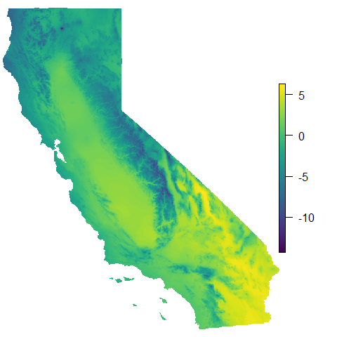

```r
# For the purposes of simplicity, let's just use one of the PCs for mapping:
envlayers <- CA_env$CA_rPCA1

par(mar = c(0, 0, 0, 0))
# Let's take a look at the map with no masking:
plot(envlayers, col = viridis(100), axes = FALSE, box = FALSE)
```

## Making masked maps

### Make a range-based based

We can use the `extrap_mask()` function to mask all areas outside range of environmental values included in data (the `"range"` argument). This argument masks conservatively, meaning that if any area falls outside the range of the data for any variable, the area is masked.

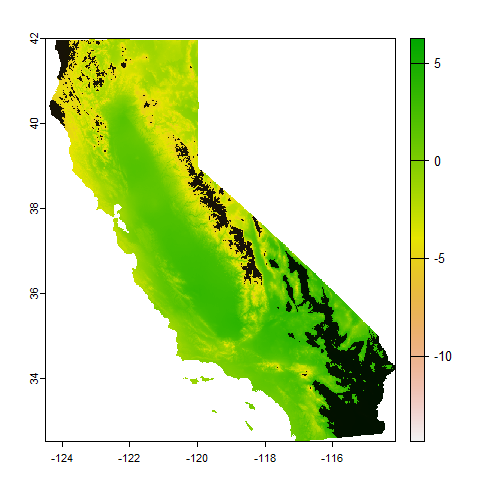

```r
par(mar = c(0, 0, 0, 0))

# Extrapolate env values for given coordinates
map_mask <- extrap_mask(liz_coords, envlayers, method = "range")
# Now, plot the map with masked areas
plot_extrap_mask(envlayers, map_mask, RGB_cols = FALSE)
```

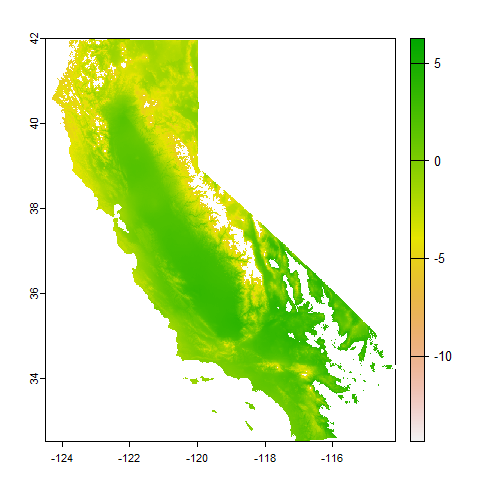

```r
# Let's make the masked areas white with no transparency
plot_extrap_mask(envlayers, map_mask, RGB_cols = FALSE, mask_col = rgb(1, 1, 1, alpha = 1))
```

### Standard deviation-based mask

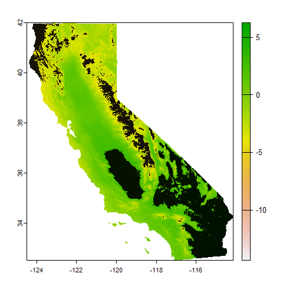

```r
par(mar = c(0, 0, 0, 0))

# Let's start with nsd=2
map_mask <- extrap_mask(liz_coords, envlayers, method = "sd", nsd = 2)
plot_extrap_mask(envlayers, map_mask, RGB = FALSE)
```

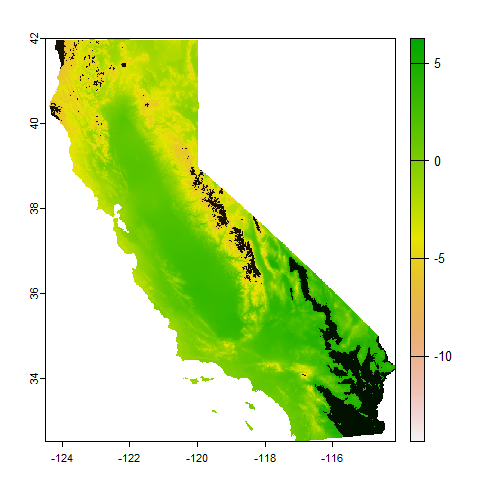

```r
# Now, increase nsd to 3 and see how the map masking changes:
map_mask <- extrap_mask(liz_coords, envlayers, method = "sd", nsd = 3)
plot_extrap_mask(envlayers, map_mask, RGB = FALSE)
```

### Buffer-based mask

We can mask all areas outside of a circular buffer of a fixed width around the coordinates provided using the `"buffer"` argument. Given how the buffer is calculated, this masking is agnostic to environment. We can adjust the size of the circular buffer using the `buffer_width` option.

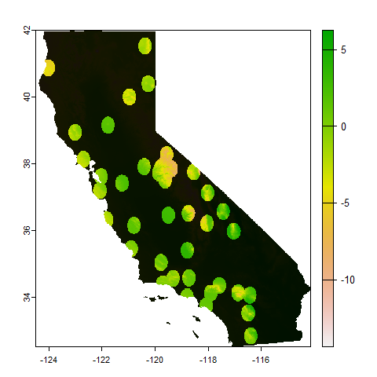

```r
par(mar = c(0, 0, 0, 0))

map_mask <- extrap_mask(liz_coords, envlayers, method = "buffer", buffer_width = 0.25)
plot_extrap_mask(envlayers, map_mask, RGB = FALSE)
```

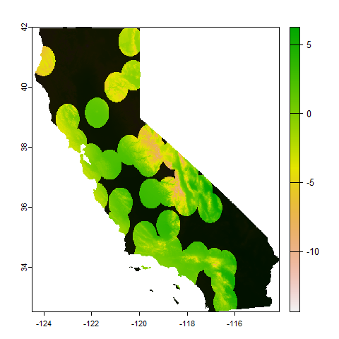

```r
# Increase buffer size
map_mask <- extrap_mask(liz_coords, envlayers, method = "buffer", buffer_width = 0.5)

plot_extrap_mask(envlayers, map_mask, RGB = FALSE)
```

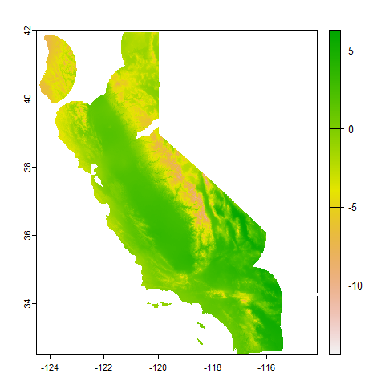

```r
# Increase buffer size and change masking color and transparency
map_mask <- extrap_mask(liz_coords, envlayers, method = "buffer", buffer_width = 1)

plot_extrap_mask(envlayers, map_mask, RGB = FALSE, mask_col = rgb(1, 1, 1, alpha = 1))
```

### Convex hull-based mask

A convex hull describes the smallest convex polygon that contains sets or points (in this case, sampling coordinates). We can mask all areas outside of a convex hull around the coordinates provided using the `"chull"` argument (this largely uses the `st_convex_hull()` function in the sf package). As with the buffer-based masking, this masking is also agnostic to environment, and the size of the buffer is once again changed with the `buffer_width` argument

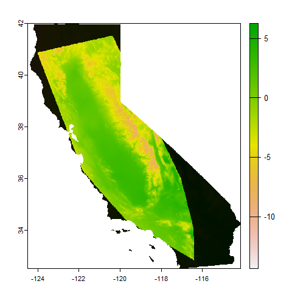

```r
par(mar = c(0, 0, 0, 0))

map_mask <- extrap_mask(liz_coords, envlayers, method = "chull")
plot_extrap_mask(envlayers, map_mask, RGB = FALSE)
```

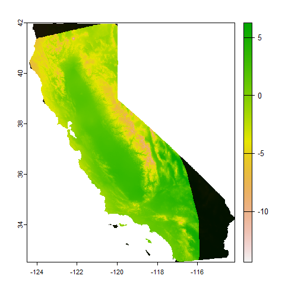

```r
# Increase the buffer size
map_mask <- extrap_mask(liz_coords, envlayers, method = "chull", buffer_width = 0.5)
plot_extrap_mask(envlayers, map_mask, RGB = FALSE)
```

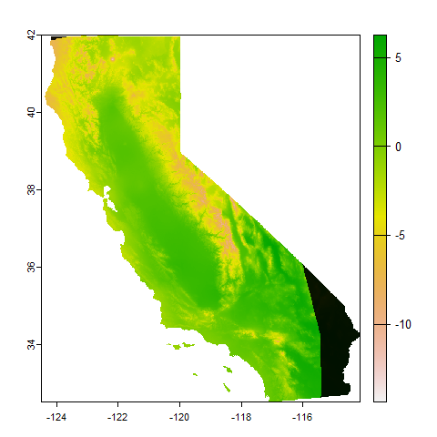

```r
# Increase the buffer size again
map_mask <- extrap_mask(liz_coords, envlayers, method = "chull", buffer_width = 1)
plot_extrap_mask(envlayers, map_mask, RGB = FALSE)
```

## Removing islands from maps using `rm_islands()`

In some cases, if we have no sampling from islands, we do not want those areas mapped at all and can use the `rm_islands()` function to do so. For example, our example dataset does not include the endemic *S. occidentalis* subspecies that occurs in the Channel Islands in California, and thus, we may want to exclude the Channel Islands from our maps. This function largely uses the `ms_filter_islands()` function in the rmapshaper package, which identifies islands based on them being small in size and detached from the larger polygon (i.e., mainland). Users can specify the size of the island to remove using the `min_vertices` argument, which is the minimum number of vertices to retain.

### Retrieve polygon

```r
par(mar = c(0, 0, 0, 0))

states <- getData("GADM", country = "United States", level = 1)
```

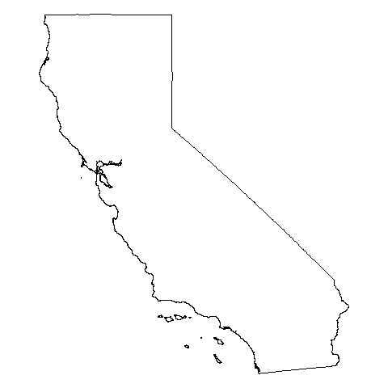

```r
# states <- gadm("United States", level = 1, path = here())
cali <- states[states$NAME_1 == "California", ]
plot(cali)
```

### Remove islands

The `rm_islands()` requires a polygon (in our case, the state of California from above) and the environmental layers we want the island(s) removed from (in our case, `CA_env` or `envlayers`).

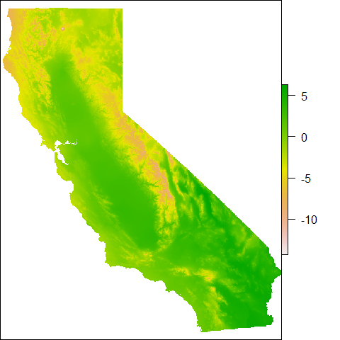

```r
par(mar = c(0, 0, 0, 0))

cali_noislands <- rm_islands(envlayers, cali)

# Now, let's plot the env layer and see how it's removed the Channel Islands
plot(cali_noislands)
```

This function works even if we have multiple layers, as with `CA_env`.

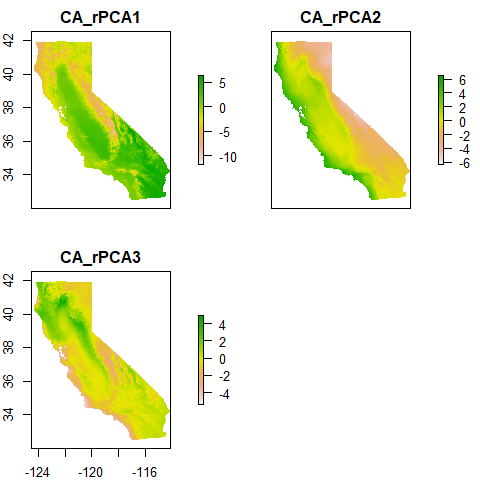

```r
par(mar = c(0, 0, 0, 0))

cali_noislands <- rm_islands(CA_env, cali)

# Islands are gone from all three enviro PC layers
plot(cali_noislands)
```